# Quantitative variables

## Weight and smoking cessation

```r
d <- rio::import("data/smoking_cessation.txt")
head(d)
```

```
   pre  pos
1 61.6 62.1
2 59.7 65.6
3 63.8 70.3
4 66.3 70.1
5 52.3 56.1
6 56.7 60.1
```

Is there a change in weight after smoking cessation?

We want to compare weight `pre`- and `pos`-smoking cessation

## Tests to compare two paired distributions

If distribution of *individual differences* is about normal\(^1\): \(\quad\) parametric test

- paired, or one-sample *t*-test

Otherwise: \(\quad\) Distribution-free (“non-parametric”) tests

- Wilcoxon signed ranks test

\(^1\) In practice, parametric test works well if:  
- distribution of *individual differences* is (approximately) symmetrical  
- no *influential* outliers

which can be inspected in a boxplot.

Paired tests are based on the *individual differences*.

## Paired data and individual differences

The mean of individual differences = difference of means

```r
library(tidyverse)
d <- mutate(d, change = pos - pre)   # compute individual differences
head(d, 3)
```

```
   pre  pos change
1 61.6 62.1    0.5
2 59.7 65.6    5.9
3 63.8 70.3    6.5
```

```r
sapply(d, mean)                      # to get the mean of all variables in d
```

```
   pre    pos change
59.676 63.592  3.916
```

`63.592 - 59.676 = 3.916`

## Boxplot (with mean overlaid)

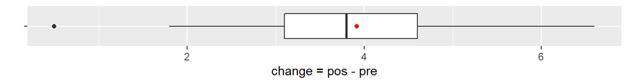

```r
library(ggformula)
gf_boxplot(change ~ "", data = d, xlab = "", ylab = "change = pos - pre") %>%
  gf_summary(fun = mean, geom = "point", color = "red") %>%
  gf_refine(coord_flip())
```

In this case:

- distribution is (approximately) symmetrical
- a single outlier in smokers, but not influential (mean \(\approx\) median)

Parametric test is OK

## Paired, or one-sample *t*-test

```r
t.test(d$change)                               # one-sample t-test on the differences
```

```
    One Sample t-test

data:  d$change
t = 12.553, df = 24, p-value = 4.893e-12
alternative hypothesis: true mean is not equal to 0
95 percent confidence interval:
 3.272134 4.559866
sample estimates:
mean of x
    3.916
```

```r
t.test(d$pos, d$pre, paired = TRUE)            # paired t-test on pos vs pre
```

```
    Paired t-test

data:  d$pos and d$pre
t = 12.553, df = 24, p-value = 4.893e-12
alternative hypothesis: true mean difference is not equal to 0
95 percent confidence interval:
 3.272134 4.559866
sample estimates:
mean difference
          3.916
```

## When conditions for the *t*-test are not met

Murder rates (per 100000 inhabitants) by gender in 198 countries

```r
load("data/murder_rates.RData")
head(d)
```

```
              country      women       men
1         Afghanistan  0.8818136  6.547783
2             Albania  2.0200360 11.469195
3             Algeria  5.9402733 13.781246
4             Andorra  0.3915673  1.060996
5              Angola 13.6770010 84.500107
6 Antigua and Barbuda  2.5507791 12.666227
```

source: https://www.gapminder.org/data/

## Differences in rates (men - women)

[figure not shown]

```r
d$difference <- d$men - d$women    # compute country differences to plot them
```

In this case:

- distribution is clearly assymmetrical
- several outliers, with influence (mean > median)

Distribution-free test (Wilcoxon signed ranks test)

## Wilcoxon signed ranks test

```r
wilcox.test(d$difference)
```

```
    Wilcoxon signed rank test with continuity correction

data:  d$difference
V = 18256, p-value < 2.2e-16
alternative hypothesis: true location is not equal to 0
```

## Exercise

Read [this file](https://raw.githubusercontent.com/acobos/Datasets/master/Life_Expectancy_with_continent.csv). This should be the first 6 lines of the resulting dataframe:

```
              Country   LE LE_men LE_women      Continent
1         Afghanistan 37.7   36.7     38.7           Asia
2             Albania 60.0   56.5     63.4         Europe
3             Algeria 61.6   62.5     60.7         Africa
4             Andorra 72.3   69.3     75.2         Europe
5              Angola 38.0   37.0     38.9         Africa
6 Antigua-and-Barbuda 65.8   63.4     68.3 America, North
```

Try to answer these questions:

1. Is life expectancy the same for men and women?
2. Provide some estimate of the difference